# Cashflow Analysis

```r
# Preparing environment
library(FinancialMath)
```

### Cashflow Statement

In order to develop a new product and place it in the market for sale, RM Group Inc. consulted you to do an investment analysis. The following table shows a similar investment made earlier by the company.

```r
Year<-c(0:10)
Contributions<-c(80000,10000,10000,10000,20000,
                 2000,2000,2000,2000,2000,0)
invReturns<-c(0,0,0,0,12000,30000,40000,
              35000,25000,15000,8000)
netCashflow<-c(invReturns-Contributions)

Cashflow<-data.frame(Year,Contributions,invReturns,netCashflow)
Cashflow
```

| Year | Contributions | invReturns | netCashflow |
| --- | --- | --- | --- |
| 0 | 80000 | 0 | -80000 |
| 1 | 10000 | 0 | -10000 |
| 2 | 10000 | 0 | -10000 |
| 3 | 10000 | 0 | -10000 |
| 4 | 20000 | 12000 | -8000 |
| 5 | 2000 | 30000 | 28000 |
| 6 | 2000 | 40000 | 38000 |
| 7 | 2000 | 35000 | 33000 |
| 8 | 2000 | 25000 | 23000 |
| 9 | 2000 | 15000 | 13000 |

[output cut: 1 more lines]

### Net Present Value

It is required to compute the Net Present Value(NPV) for the investments with a 3% interest rate per annum.

```
[1] 1488.039
```

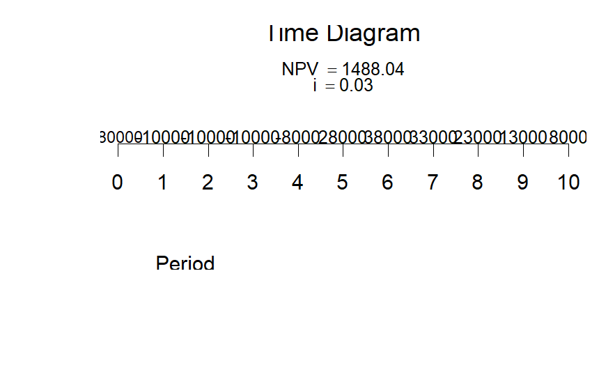

```r
par(mar=c(4,4,1,0.5))
NPV(cf0=netCashflow[1],cf=netCashflow[-1],times=Year[-1],i=0.03,plot=TRUE)
```

### Internal Rate of Return

It is also required to compute internal rate of return for the contributions.

```
[1] 0.72643855 0.03217979 0.72643855
```

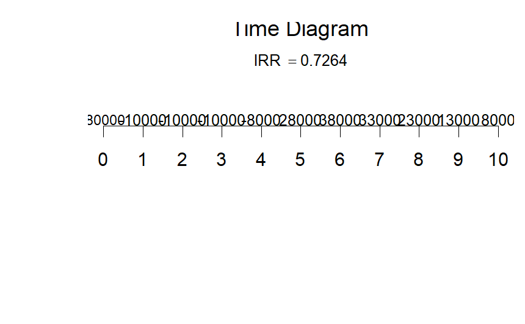

```r
par(mar=c(4,4,1,0.5))
IRR(cf0=netCashflow[1],cf=netCashflow[-1],
    times=Year[-1],plot=TRUE)
```

### Generate NPV Function

Writing own NPV function to replicate what the in-built NPV function does exempting the plot.

```r
NetPV<-function(incf,cf,i,times)
{
  incf = abs(incf)
  pv = sum(cf/(1 + i)^times)
  netpv = pv - incf
  return(netpv)
}
```

Testing function

```r
NetPV(incf=netCashflow[1],cf=netCashflow[-1],
    i=0.03,times=Year[-1])
```

```
[1] 1488.039
```

### Will the investment be viable at an interest of 15% per annum?

The investment is only viable when the net present value is a positive definite figure. To ascertain this conclusion it is required to compute the NPV at 15 per annum.

```r
NetPV(incf=netCashflow[1],cf=netCashflow[-1],
        i=0.15,times=Year[-1])
```

```
[1] -51459.33
```

Alternatively,

```r
NPV(cf0=netCashflow[1],cf=netCashflow[-1],times=Year[-1],i=0.15)
```

```
[1] -51459.33
```

At 15% per annum, the NPV is -51459.33 which is a negative definte figure. This implies that the investment is not viable at 15% interest rate per annum.